# PROYECTO 1 - RELACIÓN MINUTOS INGRESOS - GUIA 1

**Participante: Carlos Andrés Zamora León**

El presente cuaderno presentará el desarrollo de la guía 1 del curso de Machine Learning de la Maestría en Ciencia de Datos. Dentro de las actividades que desarrollaremos, introduciremos las librerías pandas, numpy y matplotlib para el preprocesamiento, visualización de un conjunto de datos y el desarrollo de algunas medidas estadísticas descriptivas.

**¿Existe relación alguna entre el total de minutos usados con la compañía y el ingreso total de los clientes?**

La revisión del comportamiento de los clientes en cualquier empresa es de vital importancia para el desarrollo de estrategias tanto de mejoramiento de productos como de publicidad y toma de decisiones. Evaluaremos la información del conjunto de registros Credito_dias.csv de una empresa de telecomunicaciones que cuenta las siguientes variables:

**totrev:** Ingresos del cliente.

**totmou:** Total de minutos usados por el cliente.

**creditcd:** Indicador de tarjeta de crédito.

**eqpdays:** Número de días (antigüedad) del equipo actual.

Es importante mencionar que la empresa contiene una gran cantidad de clientes y hacer el análisis uno a uno no es lo óptimo. Con ayuda de la programación y el análisis de datos, se logrará llegar a conclusiones rápidas y acertadas para encontrar relaciones que a simple vista no son tenidas en cuenta.

**¿Qué se quiere identificar?**

Teniendo en cuenta la información de la base de datos, se quiere identificar si hay una relación entre el total de minutos usados por el cliente con la compañía y el ingreso total de los clientes, es decir, ¿Será posible afirmar que cuando una persona tiene un mayor ingreso, entonces es mayor la utilización de minutos o todo lo contrario?

Empezaremos importando las librerías de las cuales vamos a hacer uso:

```python
import pandas as pd
import numpy as np
import matplotlib.pyplot as plt
import os
import warnings
import seaborn as sns
warnings.filterwarnings('ignore')
```

Enseguida, vamos a importar el dataframe sobre el cual vamos a realizar el tratamiento de información, encontrándose este dentro del repositorio que clonamos previamente en consola, traído de github:

```python
df=pd.read_csv("datos_01/Credito_dias.csv", sep=",",index_col="Customer_ID")
df
```

| Customer_ID | totmou | totrev | creditcd | eqpdays |
| --- | --- | --- | --- | --- |
| 1082423 | 7269.0 | 906.58 | Y | 371 |
| 1069232 | 13552.0 | 1172.25 | N | 83 |
| 1031705 | 4152.0 | 577.39 | Y | 675 |
| 1089806 | 1863.0 | 294.26 | Y | 218 |
| 1076695 | 4155.0 | 433.16 | N | 222 |
| ... | ... | ... | ... | ... |
| 1027614 | 2570.0 | 484.31 | Y | 611 |
| 1098422 | 2105.0 | 583.36 | Y | 1243 |
| 1096497 | 3690.0 | 294.29 | Y | 212 |
| 1087248 | 3333.0 | 233.08 | Y | 290 |
| 1099003 | 5025.0 | 1436.49 | Y | 1029 |

10000 rows × 4 columns

Listamos los archivos que se encuentran en el directorio principal:

```python
os.listdir()
```

```
['.ipynb_checkpoints',
 'Aprendizaje Automático.ipynb',
 'bank_marketing.csv',
 'Base Grande.csv',
 'Clase 2',
 'datos_01',
 'Ejercicio K Means.ipynb',
 'Estadisticos de Validación.ipynb',
 'Graficos.ipynb',
 'ifood_df.csv',
 'images',
 'Intro a Python y Pandas.md',
 'introduccion.md',
 'Manipulación, Limpieza y Exploración de Datos.ipynb',
 'Medidas Estadisticas.ipynb',
 'Minutos y segundos.ipynb',
 'Modelos de Clasificación I.ipynb',
 'Modelos de Clasificación II.ipynb',
 'Relacion_minutos.ipynb',
 'Visualización en Python.ipynb',
 'Árboles de decisión.ipynb']
```

Para el siguiente paso, dejaremos a nuestra disposición una serie de funciones que nos permitirán conocer datos puntuales de nuestro DataFrame, como conocer las primeras o últimas n entradas, listar columnas e índices y obtener una lista aleatoria. Como parte de la información principal que vamos a requerir del presente DataFrame para entender la naturaleza del mismo, mostraremos la dimensión del DataFrame, el tipo de registros contenidos y la información principal resumen:

```python
#df.head(n)
#df.tail(n)
#df.columns
#df.index
#df.sample(n)
display("La dimensión del Dataframe es:",df.shape)
display("Tipos de registros en el Dataframe:",df.dtypes)
df.info()
```

```
'La dimensión del Dataframe es:'
```

```
(10000, 4)
```

```
'Tipos de registros en el Dataframe:'
```

```
totmou      float64
totrev      float64
creditcd     object
eqpdays       int64
dtype: object
```

```
<class 'pandas.core.frame.DataFrame'>
Index: 10000 entries, 1082423 to 1099003
Data columns (total 4 columns):
 #   Column    Non-Null Count  Dtype
---  ------    --------------  -----
 0   totmou    10000 non-null  float64
 1   totrev    10000 non-null  float64
 2   creditcd  9848 non-null   object
 3   eqpdays   10000 non-null  int64
dtypes: float64(2), int64(1), object(1)
memory usage: 390.6+ KB
```

Usaremos la función describe para mostrar un resumen completo de la información que incluye análisis estadístico descriptivo:

```python
df.describe(include='all')
```

|  | totmou | totrev | creditcd | eqpdays |
| --- | --- | --- | --- | --- |
| count | 10000.000000 | 10000.000000 | 9848 | 10000.000000 |
| unique | NaN | NaN | 2 | NaN |
| top | NaN | NaN | Y | NaN |
| freq | NaN | NaN | 6796 | NaN |
| mean | 7692.804866 | 1042.133807 | NaN | 386.794500 |
| std | 8657.917883 | 857.144895 | NaN | 252.720196 |
| min | 0.000000 | 11.100000 | NaN | -5.000000 |
| 25% | 2576.000000 | 526.787500 | NaN | 210.000000 |
| 50% | 5262.000000 | 820.235000 | NaN | 338.000000 |
| 75% | 9823.250000 | 1272.975000 | NaN | 522.000000 |
| max | 163264.176700 | 13426.600000 | NaN | 1823.000000 |

# Manejo de datos perdidos o esperados

Encontaremos aquellas columnas donde hay información del tipo NaN, para de esta forma darle tratamiento:

```python
df.isnull().any(axis=0)
```

```
totmou      False
totrev      False
creditcd     True
eqpdays     False
dtype: bool
```

Buscamos las posiciones donde encontramos los atributos nulos y los identificamos:

```python
perd=df.isnull().any(axis=1)
perd
```

```
Customer_ID
1082423    False
1069232    False
1031705    False
1089806    False
1076695    False
           ...
1027614    False
1098422    False
1096497    False
1087248    False
1099003    False
Length: 10000, dtype: bool
```

```python
range(len(df))
```

```
range(0, 10000)
```

```python
df.index
```

```
Index([1082423, 1069232, 1031705, 1089806, 1076695, 1091652, 1043846, 1088967,
       1045239, 1046584,
       ...
       1087145, 1002540, 1044082, 1083458, 1093976, 1027614, 1098422, 1096497,
       1087248, 1099003],
      dtype='int64', name='Customer_ID', length=10000)
```

```python
for i in df.index[:10]:
    print(i)
```

```
1082423
1069232
1031705
1089806
1076695
1091652
1043846
1088967
1045239
1046584
```

```python
df[perd]
```

| Customer_ID | totmou | totrev | creditcd | eqpdays |
| --- | --- | --- | --- | --- |
| 1072218 | 5684.0 | 857.65 | NaN | 244 |
| 1066597 | 925.0 | 373.12 | NaN | 344 |
| 1023352 | 14466.0 | 2243.76 | NaN | 387 |
| 1045521 | 2504.0 | 756.79 | NaN | 495 |
| 1001813 | 76260.0 | 5526.11 | NaN | 361 |
| ... | ... | ... | ... | ... |
| 1050795 | 15591.0 | 1330.71 | NaN | 447 |
| 1096985 | 3011.0 | 522.14 | NaN | 74 |
| 1025203 | 853.0 | 650.34 | NaN | 780 |
| 1099258 | 33660.0 | 4247.85 | NaN | 206 |
| 1026149 | 1955.0 | 606.08 | NaN | 770 |

152 rows × 4 columns

```python
perdidos = df[df.isnull().any(axis=1)]
perdidos
```

| Customer_ID | totmou | totrev | creditcd | eqpdays |
| --- | --- | --- | --- | --- |
| 1072218 | 5684.0 | 857.65 | NaN | 244 |
| 1066597 | 925.0 | 373.12 | NaN | 344 |
| 1023352 | 14466.0 | 2243.76 | NaN | 387 |
| 1045521 | 2504.0 | 756.79 | NaN | 495 |
| 1001813 | 76260.0 | 5526.11 | NaN | 361 |
| ... | ... | ... | ... | ... |
| 1050795 | 15591.0 | 1330.71 | NaN | 447 |
| 1096985 | 3011.0 | 522.14 | NaN | 74 |
| 1025203 | 853.0 | 650.34 | NaN | 780 |
| 1099258 | 33660.0 | 4247.85 | NaN | 206 |
| 1026149 | 1955.0 | 606.08 | NaN | 770 |

152 rows × 4 columns

```python
df['creditcd'].value_counts(dropna=False)
```

```
creditcd
Y      6796
N      3052
NaN     152
Name: count, dtype: int64
```

```python
promedio = df['totrev'].mean()
df['totrev']=df['totrev'].replace(np.nan, promedio)
```

Reemplazaremos los valores nulos de la columna creditcd, con el atributo Y y verificaremos que ya no contamos con valores nulos:

```python
df['creditcd'].fillna("Y",inplace=True)
```

```python
df.info()
```

```
<class 'pandas.core.frame.DataFrame'>
Index: 10000 entries, 1082423 to 1099003
Data columns (total 4 columns):
 #   Column    Non-Null Count  Dtype
---  ------    --------------  -----
 0   totmou    10000 non-null  float64
 1   totrev    10000 non-null  float64
 2   creditcd  10000 non-null  object
 3   eqpdays   10000 non-null  int64
dtypes: float64(2), int64(1), object(1)
memory usage: 390.6+ KB
```

```python
df.isnull().any(axis=0)
```

```
totmou      False
totrev      False
creditcd    False
eqpdays     False
dtype: bool
```

```python
df
```

| Customer_ID | totmou | totrev | creditcd | eqpdays |
| --- | --- | --- | --- | --- |
| 1082423 | 7269.0 | 906.58 | Y | 371 |
| 1069232 | 13552.0 | 1172.25 | N | 83 |
| 1031705 | 4152.0 | 577.39 | Y | 675 |
| 1089806 | 1863.0 | 294.26 | Y | 218 |
| 1076695 | 4155.0 | 433.16 | N | 222 |
| ... | ... | ... | ... | ... |
| 1027614 | 2570.0 | 484.31 | Y | 611 |
| 1098422 | 2105.0 | 583.36 | Y | 1243 |
| 1096497 | 3690.0 | 294.29 | Y | 212 |
| 1087248 | 3333.0 | 233.08 | Y | 290 |
| 1099003 | 5025.0 | 1436.49 | Y | 1029 |

10000 rows × 4 columns

## Cálculo de estadísticas resumen

Las medidas estadísticas resumen son de gran ayuda para comprender como es el comportamiento de la distribución de los datos, los objetos DataFrame ofrecen facilidades para hacer el cálculo de algunas estadísticas sobre cada una de las variables.

```python
df['creditcd'].value_counts(dropna=False)
```

```
creditcd
Y    6948
N    3052
Name: count, dtype: int64
```

La exploración del siguiente resultado puede mostrar inconsistencias en los registros y nos ayudará a tomar decisiones sobre algunos registros, el valor mínimo de la variable eqpdays (Número de días (antigüedad) del equipo actual) debería ser estrictamente positivo y estos pueden ser errores de ingreso:

```python
df["eqpdays"]=[0 if i<0 else i for i in df["eqpdays"] ]
```

```python
df.describe(include='all')
```

|  | totmou | totrev | creditcd | eqpdays |
| --- | --- | --- | --- | --- |
| count | 10000.000000 | 10000.000000 | 10000 | 10000.00000 |
| unique | NaN | NaN | 2 | NaN |
| top | NaN | NaN | Y | NaN |
| freq | NaN | NaN | 6948 | NaN |
| mean | 7692.804866 | 1042.133807 | NaN | 386.79920 |
| std | 8657.917883 | 857.144895 | NaN | 252.71297 |
| min | 0.000000 | 11.100000 | NaN | 0.00000 |
| 25% | 2576.000000 | 526.787500 | NaN | 210.00000 |
| 50% | 5262.000000 | 820.235000 | NaN | 338.00000 |
| 75% | 9823.250000 | 1272.975000 | NaN | 522.00000 |
| max | 163264.176700 | 13426.600000 | NaN | 1823.00000 |

### Agregar información de múltiples tablas

Hemos desarrollado un breve resumen estadístico solamente usando la base `Credito_dias.csv`. Realizaremos la combinación de las 19 áreas que nos reportan en los archivos csv. Una forma de lograr esta tarea de agregación es usar el método pd.concat() de pandas. Una entrada en este método puede ser una lista de DataFrames que quiera concatenar. Usaremos un ciclo `for` sobre cada uno de los archivos de áreas para crear un Dataframe temporal que permita concatenar la totalidad de información con la que disponemos.

```python
areas=list(os.listdir("datos_01"))
try:
    areas.remove('.ipynb_checkpoints')
except:
    pass

try:
    areas.remove('Credito_dias.csv')
except:
    pass
areas=[i for i in areas if i.count('.csv')>=1 ]
areas
```

```
['ATLANTIC SOUTH AREA.csv',
 'CALIFORNIA NORTH AREA.csv',
 'CENTRAL-SOUTH TEXAS AREA.csv',
 'CHICAGO AREA.csv',
 'DALLAS AREA.csv',
 'DC-MARYLAND-VIRGINIA AREA.csv',
 'GREAT LAKES AREA.csv',
 'HOUSTON AREA.csv',
 'LOS ANGELES AREA.csv',
 'MIDWEST AREA.csv',
 'NEW ENGLAND AREA.csv',
 'NEW YORK CITY AREA.csv',
 'NORTH FLORIDA AREA.csv',
 'NORTHWEST-ROCKY MOUNTAIN AREA.csv',
 'OHIO AREA.csv',
 'PHILADELPHIA AREA.csv',
 'SOUTH FLORIDA AREA.csv',
 'SOUTHWEST AREA.csv',
 'TENNESSEE AREA.csv']
```

```python
print("Definición de los símbolos de las acciones")

lista_df = []
# Bucle sobre los símbolos
#print(" --- Inicie el bucle sobre los símbolos --- ")
for i in areas:
    ## ruta completa
    i='datos_01/'+i
    print(i)
    #print("Procesando el símbolo: " + i)
    temp_df = pd.read_csv(i,index_col="Customer_ID")
    temp_df["area"] = i
    lista_df.append(temp_df)
    # Usando un salto de línea al final de esta cadena de caracteres por estética
   # print(" --- Bucle completo sobre los símbolos --- \n")
    # Combinando en un solo DataFrame usando el concat

print("Agregando los datos")
agr_df = pd.concat(lista_df, axis=0)
print(agr_df.shape)
print("Cabeza del DataFrame agr_df: ")
agr_df.head()
```

```
Definición de los símbolos de las acciones
datos_01/ATLANTIC SOUTH AREA.csv
datos_01/CALIFORNIA NORTH AREA.csv
datos_01/CENTRAL-SOUTH TEXAS AREA.csv
datos_01/CHICAGO AREA.csv
datos_01/DALLAS AREA.csv
datos_01/DC-MARYLAND-VIRGINIA AREA.csv
datos_01/GREAT LAKES AREA.csv
datos_01/HOUSTON AREA.csv
datos_01/LOS ANGELES AREA.csv
datos_01/MIDWEST AREA.csv
datos_01/NEW ENGLAND AREA.csv
datos_01/NEW YORK CITY AREA.csv
datos_01/NORTH FLORIDA AREA.csv
datos_01/NORTHWEST-ROCKY MOUNTAIN AREA.csv
datos_01/OHIO AREA.csv
datos_01/PHILADELPHIA AREA.csv
datos_01/SOUTH FLORIDA AREA.csv
datos_01/SOUTHWEST AREA.csv
datos_01/TENNESSEE AREA.csv
Agregando los datos
(9997, 4)
Cabeza del DataFrame agr_df:
```

| Customer_ID | custcare_Mean | new_cell | area | creditcd |
| --- | --- | --- | --- | --- |
| 1069232 | 3.666667 | U | datos_01/ATLANTIC SOUTH AREA.csv | N |
| 1043846 | 0.000000 | U | datos_01/ATLANTIC SOUTH AREA.csv | Y |
| 1008539 | 0.000000 | N | datos_01/ATLANTIC SOUTH AREA.csv | Y |
| 1068315 | 0.000000 | U | datos_01/ATLANTIC SOUTH AREA.csv | N |
| 1074220 | 1.666667 | U | datos_01/ATLANTIC SOUTH AREA.csv | N |

Hacemos que el texto mostrado sea visualmente más fácil de interpretar:

```python
texto=r"datos_01/"
agr_df['area']=agr_df['area'].str.replace(texto , '').str.replace(" AREA.csv","")
agr_df
```

| Customer_ID | custcare_Mean | new_cell | area | creditcd |
| --- | --- | --- | --- | --- |
| 1069232 | 3.666667 | U | ATLANTIC SOUTH | N |
| 1043846 | 0.000000 | U | ATLANTIC SOUTH | Y |
| 1008539 | 0.000000 | N | ATLANTIC SOUTH | Y |
| 1068315 | 0.000000 | U | ATLANTIC SOUTH | N |
| 1074220 | 1.666667 | U | ATLANTIC SOUTH | N |
| ... | ... | ... | ... | ... |
| 1093180 | 3.000000 | U | TENNESSEE | Y |
| 1018795 | 0.000000 | U | TENNESSEE | Y |
| 1055110 | 9.666667 | U | TENNESSEE | N |
| 1078247 | 0.333333 | U | TENNESSEE | Y |
| 1061746 | 0.000000 | U | TENNESSEE | Y |

9997 rows × 4 columns

Mostramos la información en orden ascendente filtrando por Customer_ID:

```python
agr_df.sort_index(axis=0,inplace=True)
agr_df.to_csv('Base Grande.csv')
agr_df
```

| Customer_ID | custcare_Mean | new_cell | area | creditcd |
| --- | --- | --- | --- | --- |
| 1000014 | 0.000000 | Y | CENTRAL-SOUTH TEXAS | N |
| 1000016 | 1.000000 | N | DALLAS | Y |
| 1000021 | 0.333333 | U | TENNESSEE | Y |
| 1000023 | 0.000000 | N | NORTHWEST-ROCKY MOUNTAIN | N |
| 1000029 | 0.000000 | N | NEW ENGLAND | Y |
| ... | ... | ... | ... | ... |
| 1099907 | 17.333333 | U | LOS ANGELES | Y |
| 1099932 | 0.000000 | U | LOS ANGELES | Y |
| 1099963 | 0.000000 | U | SOUTHWEST | Y |
| 1099981 | 0.333333 | U | SOUTHWEST | NaN |
| 1099992 | 0.000000 | Y | LOS ANGELES | Y |

9997 rows × 4 columns

## Cruce de información

El cruce de información es una operación esencial en el análisis de los datos. Usualmente, la posibilidad de realizar el cruce de dos o más fuentes de información es el primer paso para responder preguntas complejas acerca de los datos. Existen muchas formas de cruzar o combinar tablas de datos. El cruce de estos datos siempre tiene un propósito. Por tanto, se debe realizar un análisis de lo que se requiere antes de iniciar. Para esto, lo primero es conocer bien las fuentes de información que se van a relacionar.

### Uniones (Joins)

Usando la librería pandas se pueden realizar 4 tipos de uniones para cruzar información entre dos fuentes de datos, ver Figura abajo.

- INNER JOIN: este tipo de cruce incluye solo los resgistros que coincieden en las dos tablas
- LEFT JOIN: en este tipo de cruce se incluyen todos los registros de la primera tabla aunque no aparezcan coincidencias en la segunda. Cuando no hay coincidencias en la segunda tabla los campos correspondientes a esta aparecerán como nulos.
- RIGHT JOIN: en este tipo de cruce se incluyen todos los registros de la segunda tabla aunque no aparezcan coincidencias en la primera. Cuando no hay coincidencias en la primer tabla los campos correspondientes a esta aparecerán como nulos.
- OUTER JOIN O FULL JOIN: combina todos los registros de ambas tablas aunque no existan coincidencias en la otra tabla.

[figure not shown]

La combinación a usar depende del análisis que se requiera con los datos. Lo más común es realizar un cruce de tipo Inner Join, debido a que muestra los registros cuando aparecen relacionados en ambas tablas. Sin embargo, en ocasiones se quiere saber que pasa con todos los registros de la primera tabla aunque no se tengan coincidencias. Alternativamente, quizá, lo menos usual es hacer combinaciones de tipo RIGHT o OUTER. Generalmente, estas son usadas cuando se quiere saber por qué no se tienen coincidencias, o cuáles registros no cumplen con la relación especificada.

Ya que desconocemos cuales son los registros perdidos en los 2 dataframes que hemos construido y es necesario para continuar nuestro preprocesamiento el unir la información.

Resetearemos los índices de los DataFrame original y el nuevo construido:

```python
agr_df=agr_df.reset_index()
agr_df
```

|  | Customer_ID | custcare_Mean | new_cell | area | creditcd |
| --- | --- | --- | --- | --- | --- |
| 0 | 1000014 | 0.000000 | Y | CENTRAL-SOUTH TEXAS | N |
| 1 | 1000016 | 1.000000 | N | DALLAS | Y |
| 2 | 1000021 | 0.333333 | U | TENNESSEE | Y |
| 3 | 1000023 | 0.000000 | N | NORTHWEST-ROCKY MOUNTAIN | N |
| 4 | 1000029 | 0.000000 | N | NEW ENGLAND | Y |
| ... | ... | ... | ... | ... | ... |
| 9992 | 1099907 | 17.333333 | U | LOS ANGELES | Y |
| 9993 | 1099932 | 0.000000 | U | LOS ANGELES | Y |
| 9994 | 1099963 | 0.000000 | U | SOUTHWEST | Y |
| 9995 | 1099981 | 0.333333 | U | SOUTHWEST | NaN |
| 9996 | 1099992 | 0.000000 | Y | LOS ANGELES | Y |

9997 rows × 5 columns

```python
df=df.reset_index()
```

```python
df2=df.copy()
```

```python
df
```

|  | Customer_ID | totmou | totrev | creditcd | eqpdays |
| --- | --- | --- | --- | --- | --- |
| 0 | 1082423 | 7269.0 | 906.58 | Y | 371 |
| 1 | 1069232 | 13552.0 | 1172.25 | N | 83 |
| 2 | 1031705 | 4152.0 | 577.39 | Y | 675 |
| 3 | 1089806 | 1863.0 | 294.26 | Y | 218 |
| 4 | 1076695 | 4155.0 | 433.16 | N | 222 |
| ... | ... | ... | ... | ... | ... |
| 9995 | 1027614 | 2570.0 | 484.31 | Y | 611 |
| 9996 | 1098422 | 2105.0 | 583.36 | Y | 1243 |
| 9997 | 1096497 | 3690.0 | 294.29 | Y | 212 |
| 9998 | 1087248 | 3333.0 | 233.08 | Y | 290 |
| 9999 | 1099003 | 5025.0 | 1436.49 | Y | 1029 |

10000 rows × 5 columns

```python
# A manera de ejemplo, y para entender el funcionamiento completo de los joint, se puede proponer un ejercicio en el que alteramos una de las variables, en este caso el Customer_ID, con el fin de generar datos que no están en ninguna de las dos tablas, de manera que no gererarían coincidencias.
#for i in df2.index[:10]:
    #df['Customer_ID'][i]=df['Customer_ID'][i]+10
```

Realizaremos el análisis exploratorio que implica generar los diferentes tipos de joint:

### Análisis por derecha

Empezando con el análisis por derecha, vemos el resultado del joint:

```python
DF_Derecha=pd.merge(df,agr_df,how='right',left_on='Customer_ID',right_on='Customer_ID')
DF_Derecha
```

|  | Customer_ID | totmou | totrev | creditcd_x | eqpdays | custcare_Mean | new_cell | area | creditcd_y |
| --- | --- | --- | --- | --- | --- | --- | --- | --- | --- |
| 0 | 1000014 | 642.00000 | 1370.94 | N | 354 | 0.000000 | Y | CENTRAL-SOUTH TEXAS | N |
| 1 | 1000016 | 15226.03000 | 2311.08 | Y | 697 | 1.000000 | N | DALLAS | Y |
| 2 | 1000021 | 79406.01667 | 6751.70 | Y | 143 | 0.333333 | U | TENNESSEE | Y |
| 3 | 1000023 | 64174.80667 | 7419.73 | N | 350 | 0.000000 | N | NORTHWEST-ROCKY MOUNTAIN | N |
| 4 | 1000029 | 42715.00000 | 3829.33 | Y | 183 | 0.000000 | N | NEW ENGLAND | Y |
| ... | ... | ... | ... | ... | ... | ... | ... | ... | ... |
| 9992 | 1099907 | 17843.00000 | 1457.01 | Y | 184 | 17.333333 | U | LOS ANGELES | Y |
| 9993 | 1099932 | 14079.00000 | 1538.55 | Y | 275 | 0.000000 | U | LOS ANGELES | Y |
| 9994 | 1099963 | 9722.00000 | 1559.16 | Y | 946 | 0.000000 | U | SOUTHWEST | Y |
| 9995 | 1099981 | 7248.00000 | 1417.30 | Y | 882 | 0.333333 | U | SOUTHWEST | NaN |
| 9996 | 1099992 | 7338.00000 | 1198.48 | Y | 773 | 0.000000 | Y | LOS ANGELES | Y |

9997 rows × 9 columns

### Análisis por izquierda

Replicamos el anterior análisis para un left joint:

```python
DF_Izq=pd.merge(df,agr_df,how='left',left_on='Customer_ID',right_on='Customer_ID')
DF_Izq
```

|  | Customer_ID | totmou | totrev | creditcd_x | eqpdays | custcare_Mean | new_cell | area | creditcd_y |
| --- | --- | --- | --- | --- | --- | --- | --- | --- | --- |
| 0 | 1082423 | 7269.0 | 906.58 | Y | 371 | 14.333333 | U | NEW ENGLAND | Y |
| 1 | 1069232 | 13552.0 | 1172.25 | N | 83 | 3.666667 | U | ATLANTIC SOUTH | N |
| 2 | 1031705 | 4152.0 | 577.39 | Y | 675 | 3.000000 | U | NEW YORK CITY | Y |
| 3 | 1089806 | 1863.0 | 294.26 | Y | 218 | 11.000000 | U | CHICAGO | Y |
| 4 | 1076695 | 4155.0 | 433.16 | N | 222 | 0.000000 | U | NORTH FLORIDA | N |
| ... | ... | ... | ... | ... | ... | ... | ... | ... | ... |
| 9995 | 1027614 | 2570.0 | 484.31 | Y | 611 | 0.666667 | U | CHICAGO | Y |
| 9996 | 1098422 | 2105.0 | 583.36 | Y | 1243 | 0.000000 | U | SOUTHWEST | Y |
| 9997 | 1096497 | 3690.0 | 294.29 | Y | 212 | 0.666667 | Y | NEW ENGLAND | Y |
| 9998 | 1087248 | 3333.0 | 233.08 | Y | 290 | 0.000000 | U | CALIFORNIA NORTH | Y |
| 9999 | 1099003 | 5025.0 | 1436.49 | Y | 1029 | 0.333333 | U | LOS ANGELES | Y |

10000 rows × 9 columns

### Análisis outer

```python
DF_Full=pd.merge(df,agr_df,how='outer',left_on='Customer_ID',right_on='Customer_ID')
DF_Full
```

|  | Customer_ID | totmou | totrev | creditcd_x | eqpdays | custcare_Mean | new_cell | area | creditcd_y |
| --- | --- | --- | --- | --- | --- | --- | --- | --- | --- |
| 0 | 1082423 | 7269.0 | 906.58 | Y | 371 | 14.333333 | U | NEW ENGLAND | Y |
| 1 | 1069232 | 13552.0 | 1172.25 | N | 83 | 3.666667 | U | ATLANTIC SOUTH | N |
| 2 | 1031705 | 4152.0 | 577.39 | Y | 675 | 3.000000 | U | NEW YORK CITY | Y |
| 3 | 1089806 | 1863.0 | 294.26 | Y | 218 | 11.000000 | U | CHICAGO | Y |
| 4 | 1076695 | 4155.0 | 433.16 | N | 222 | 0.000000 | U | NORTH FLORIDA | N |
| ... | ... | ... | ... | ... | ... | ... | ... | ... | ... |
| 9995 | 1027614 | 2570.0 | 484.31 | Y | 611 | 0.666667 | U | CHICAGO | Y |
| 9996 | 1098422 | 2105.0 | 583.36 | Y | 1243 | 0.000000 | U | SOUTHWEST | Y |
| 9997 | 1096497 | 3690.0 | 294.29 | Y | 212 | 0.666667 | Y | NEW ENGLAND | Y |
| 9998 | 1087248 | 3333.0 | 233.08 | Y | 290 | 0.000000 | U | CALIFORNIA NORTH | Y |
| 9999 | 1099003 | 5025.0 | 1436.49 | Y | 1029 | 0.333333 | U | LOS ANGELES | Y |

10000 rows × 9 columns

### Análisis inner

```python
DF_Bien=pd.merge(df,agr_df,how='inner',left_on='Customer_ID',right_on='Customer_ID')
DF_Bien
```

|  | Customer_ID | totmou | totrev | creditcd_x | eqpdays | custcare_Mean | new_cell | area | creditcd_y |
| --- | --- | --- | --- | --- | --- | --- | --- | --- | --- |
| 0 | 1082423 | 7269.0 | 906.58 | Y | 371 | 14.333333 | U | NEW ENGLAND | Y |
| 1 | 1069232 | 13552.0 | 1172.25 | N | 83 | 3.666667 | U | ATLANTIC SOUTH | N |
| 2 | 1031705 | 4152.0 | 577.39 | Y | 675 | 3.000000 | U | NEW YORK CITY | Y |
| 3 | 1089806 | 1863.0 | 294.26 | Y | 218 | 11.000000 | U | CHICAGO | Y |
| 4 | 1076695 | 4155.0 | 433.16 | N | 222 | 0.000000 | U | NORTH FLORIDA | N |
| ... | ... | ... | ... | ... | ... | ... | ... | ... | ... |
| 9992 | 1027614 | 2570.0 | 484.31 | Y | 611 | 0.666667 | U | CHICAGO | Y |
| 9993 | 1098422 | 2105.0 | 583.36 | Y | 1243 | 0.000000 | U | SOUTHWEST | Y |
| 9994 | 1096497 | 3690.0 | 294.29 | Y | 212 | 0.666667 | Y | NEW ENGLAND | Y |
| 9995 | 1087248 | 3333.0 | 233.08 | Y | 290 | 0.000000 | U | CALIFORNIA NORTH | Y |
| 9996 | 1099003 | 5025.0 | 1436.49 | Y | 1029 | 0.333333 | U | LOS ANGELES | Y |

9997 rows × 9 columns

Determinaremos qué registros no cruzaron, analizando las entradas vacías para cada joint:

```python
DF_Derecha.info()
#Vemos que los NaN se encuentran en la columna creditcd_y
```

```
<class 'pandas.core.frame.DataFrame'>
RangeIndex: 9997 entries, 0 to 9996
Data columns (total 9 columns):
 #   Column         Non-Null Count  Dtype
---  ------         --------------  -----
 0   Customer_ID    9997 non-null   int64
 1   totmou         9997 non-null   float64
 2   totrev         9997 non-null   float64
 3   creditcd_x     9997 non-null   object
 4   eqpdays        9997 non-null   int64
 5   custcare_Mean  9997 non-null   float64
 6   new_cell       9997 non-null   object
 7   area           9997 non-null   object
 8   creditcd_y     9845 non-null   object
dtypes: float64(3), int64(2), object(4)
memory usage: 703.0+ KB
```

```python
DF_Izq.info()
#Vemos que los NaN se encuentran en las columnas custcare_Mean, new_cell, area, creditcd_y
```

```
<class 'pandas.core.frame.DataFrame'>
RangeIndex: 10000 entries, 0 to 9999
Data columns (total 9 columns):
 #   Column         Non-Null Count  Dtype
---  ------         --------------  -----
 0   Customer_ID    10000 non-null  int64
 1   totmou         10000 non-null  float64
 2   totrev         10000 non-null  float64
 3   creditcd_x     10000 non-null  object
 4   eqpdays        10000 non-null  int64
 5   custcare_Mean  9997 non-null   float64
 6   new_cell       9997 non-null   object
 7   area           9997 non-null   object
 8   creditcd_y     9845 non-null   object
dtypes: float64(3), int64(2), object(4)
memory usage: 703.3+ KB
```

```python
DF_Full.info()
#Vemos que los NaN se encuentran en las columnas custcare_Mean, new_cell, area, creditcd_y
```

```
<class 'pandas.core.frame.DataFrame'>
RangeIndex: 10000 entries, 0 to 9999
Data columns (total 9 columns):
 #   Column         Non-Null Count  Dtype
---  ------         --------------  -----
 0   Customer_ID    10000 non-null  int64
 1   totmou         10000 non-null  float64
 2   totrev         10000 non-null  float64
 3   creditcd_x     10000 non-null  object
 4   eqpdays        10000 non-null  int64
 5   custcare_Mean  9997 non-null   float64
 6   new_cell       9997 non-null   object
 7   area           9997 non-null   object
 8   creditcd_y     9845 non-null   object
dtypes: float64(3), int64(2), object(4)
memory usage: 703.3+ KB
```

```python
DF_Bien.info()
#Vemos que los NaN se encuentran en la columna  creditcd_y
```

```
<class 'pandas.core.frame.DataFrame'>
RangeIndex: 9997 entries, 0 to 9996
Data columns (total 9 columns):
 #   Column         Non-Null Count  Dtype
---  ------         --------------  -----
 0   Customer_ID    9997 non-null   int64
 1   totmou         9997 non-null   float64
 2   totrev         9997 non-null   float64
 3   creditcd_x     9997 non-null   object
 4   eqpdays        9997 non-null   int64
 5   custcare_Mean  9997 non-null   float64
 6   new_cell       9997 non-null   object
 7   area           9997 non-null   object
 8   creditcd_y     9845 non-null   object
dtypes: float64(3), int64(2), object(4)
memory usage: 703.0+ KB
```

De esta manera podemos filtrar puntualmente por los registors nulos en cada uno de los joint:

```python
DF_Derecha[DF_Derecha['creditcd_y'].isna()]
```

|  | Customer_ID | totmou | totrev | creditcd_x | eqpdays | custcare_Mean | new_cell | area | creditcd_y |
| --- | --- | --- | --- | --- | --- | --- | --- | --- | --- |
| 50 | 1000429 | 20087.30000 | 3997.36 | Y | 1554 | 0.666667 | U | CENTRAL-SOUTH TEXAS | NaN |
| 66 | 1000565 | 23229.00000 | 2971.12 | Y | 382 | 0.000000 | Y | GREAT LAKES | NaN |
| 74 | 1000611 | 18053.22333 | 2496.43 | Y | 81 | 0.000000 | N | OHIO | NaN |
| 151 | 1001530 | 4085.40000 | 2134.50 | Y | 341 | 0.000000 | N | NEW ENGLAND | NaN |
| 162 | 1001667 | 16865.02000 | 2085.94 | Y | 579 | 0.333333 | Y | NEW ENGLAND | NaN |
| ... | ... | ... | ... | ... | ... | ... | ... | ... | ... |
| 9839 | 1098354 | 5501.00000 | 1247.15 | Y | 71 | 1.666667 | U | LOS ANGELES | NaN |
| 9843 | 1098457 | 2404.00000 | 945.22 | Y | 1233 | 0.666667 | U | LOS ANGELES | NaN |
| 9920 | 1099258 | 33660.00000 | 4247.85 | Y | 206 | 0.333333 | U | LOS ANGELES | NaN |
| 9965 | 1099646 | 23809.00000 | 2570.51 | Y | 149 | 0.000000 | U | LOS ANGELES | NaN |
| 9995 | 1099981 | 7248.00000 | 1417.30 | Y | 882 | 0.333333 | U | SOUTHWEST | NaN |

152 rows × 9 columns

```python
DF_Izq[DF_Izq['area'].isna()]
```

|  | Customer_ID | totmou | totrev | creditcd_x | eqpdays | custcare_Mean | new_cell | area | creditcd_y |
| --- | --- | --- | --- | --- | --- | --- | --- | --- | --- |
| 3381 | 1050270 | 1409.0 | 407.02 | Y | 102 | NaN | NaN | NaN | NaN |
| 4281 | 1020629 | 15284.0 | 2370.62 | N | 445 | NaN | NaN | NaN | NaN |
| 7384 | 1020451 | 3604.0 | 662.42 | Y | 675 | NaN | NaN | NaN | NaN |

```python
DF_Full[DF_Full['area'].isna()]
```

|  | Customer_ID | totmou | totrev | creditcd_x | eqpdays | custcare_Mean | new_cell | area | creditcd_y |
| --- | --- | --- | --- | --- | --- | --- | --- | --- | --- |
| 3381 | 1050270 | 1409.0 | 407.02 | Y | 102 | NaN | NaN | NaN | NaN |
| 4281 | 1020629 | 15284.0 | 2370.62 | N | 445 | NaN | NaN | NaN | NaN |
| 7384 | 1020451 | 3604.0 | 662.42 | Y | 675 | NaN | NaN | NaN | NaN |

```python
DF_Bien[DF_Bien['creditcd_y'].isna()]
```

|  | Customer_ID | totmou | totrev | creditcd_x | eqpdays | custcare_Mean | new_cell | area | creditcd_y |
| --- | --- | --- | --- | --- | --- | --- | --- | --- | --- |
| 44 | 1072218 | 5684.0 | 857.65 | Y | 244 | 4.000000 | U | MIDWEST | NaN |
| 47 | 1066597 | 925.0 | 373.12 | Y | 344 | 0.000000 | U | SOUTHWEST | NaN |
| 127 | 1023352 | 14466.0 | 2243.76 | Y | 387 | 0.000000 | U | MIDWEST | NaN |
| 253 | 1045521 | 2504.0 | 756.79 | Y | 495 | 0.000000 | U | SOUTH FLORIDA | NaN |
| 427 | 1001813 | 76260.0 | 5526.11 | Y | 361 | 0.000000 | N | MIDWEST | NaN |
| ... | ... | ... | ... | ... | ... | ... | ... | ... | ... |
| 9425 | 1050795 | 15591.0 | 1330.71 | Y | 447 | 1.333333 | U | HOUSTON | NaN |
| 9558 | 1096985 | 3011.0 | 522.14 | Y | 74 | 0.000000 | U | LOS ANGELES | NaN |
| 9631 | 1025203 | 853.0 | 650.34 | Y | 780 | 0.000000 | U | DC-MARYLAND-VIRGINIA | NaN |
| 9780 | 1099258 | 33660.0 | 4247.85 | Y | 206 | 0.333333 | U | LOS ANGELES | NaN |
| 9946 | 1026149 | 1955.0 | 606.08 | Y | 770 | 0.000000 | N | DC-MARYLAND-VIRGINIA | NaN |

152 rows × 9 columns

### Agrupación por área geográfica

En el Analisis de la información se suelen usar funciones de resumen, las cuales plantean el agrupamiento de ciertas características por categorías.

Para nuestro desarrollo es de interés el revisar si el comportamiento de las variables se mantiene en cada una de las áreas geográficas.

```python
DF_Bien[DF_Bien['area']=='CALIFORNIA NORTH']['creditcd_x'].value_counts(dropna=False).index
```

```
Index(['Y', 'N'], dtype='object', name='creditcd_x')
```

```python
Agrupacion=DF_Bien.groupby("area").agg({'Customer_ID':'count','totmou':['sum','mean'],'creditcd_x':[(lambda x : x.value_counts().Y),(lambda x : x.value_counts().N)]})
Agrupacion.columns=['Número de clientes','Consumo total de minutos','Consumo Promedio Minutos','Con Credito','Sin Credito']
```

```python
Agrupacion
```

| area | Número de clientes | Consumo total de minutos | Consumo Promedio Minutos | Con Credito | Sin Credito |
| --- | --- | --- | --- | --- | --- |
| ATLANTIC SOUTH | 592 | 4.057882e+06 | 6854.530794 | 381 | 211 |
| CALIFORNIA NORTH | 599 | 4.531287e+06 | 7564.752666 | 407 | 192 |
| CENTRAL-SOUTH TEXAS | 409 | 3.834537e+06 | 9375.395933 | 287 | 122 |
| CHICAGO | 496 | 3.243853e+06 | 6540.026626 | 329 | 167 |
| DALLAS | 518 | 4.791310e+06 | 9249.633771 | 373 | 145 |
| DC-MARYLAND-VIRGINIA | 640 | 4.287264e+06 | 6698.850000 | 437 | 203 |
| GREAT LAKES | 488 | 3.664937e+06 | 7510.116803 | 362 | 126 |
| HOUSTON | 458 | 4.303245e+06 | 9395.732285 | 338 | 120 |
| LOS ANGELES | 671 | 5.055043e+06 | 7533.596125 | 461 | 210 |
| MIDWEST | 685 | 5.153547e+06 | 7523.426866 | 504 | 181 |
| NEW ENGLAND | 525 | 3.499815e+06 | 6666.315124 | 371 | 154 |
| NEW YORK CITY | 1145 | 9.539892e+06 | 8331.783604 | 788 | 357 |
| NORTH FLORIDA | 442 | 2.867480e+06 | 6487.511312 | 305 | 137 |
| NORTHWEST-ROCKY MOUNTAIN | 429 | 3.315077e+06 | 7727.451562 | 281 | 148 |
| OHIO | 437 | 2.927894e+06 | 6699.986857 | 330 | 107 |
| PHILADELPHIA | 245 | 1.728323e+06 | 7054.378748 | 177 | 68 |
| SOUTH FLORIDA | 366 | 3.406319e+06 | 9306.883761 | 257 | 109 |
| SOUTHWEST | 584 | 4.589988e+06 | 7859.568516 | 371 | 213 |
| TENNESSEE | 268 | 2.110056e+06 | 7873.344950 | 187 | 81 |

Aquí, el objeto DataFrameGroupBy contiene un objeto DataFrame para cada grupo (en este caso, un objeto DataFrame para cada símbolo). Específicamente, cada elemento del objeto es una tupla que contiene el identificador de grupo (en este caso el símbolo), y las filas correspondientes del DataFrame que tienen ese símbolo.

La librería `pandas` permite iterar sobre el objeto groupby() para ver lo que hay dentro:

```python
group_df = DF_Bien.groupby(["area"]) # Datos del grupo en DF_Bien filtrados por el área
# Haciendo un bucle a través de los grupos
for item in group_df:
    print(type(item)) # Mostrando el tipo de artículo en DF_Bien
    print(item[0]) # área
    print(item[1].head()) # DataFrame
```

```
<class 'tuple'>
('ATLANTIC SOUTH',)
    Customer_ID   totmou   totrev creditcd_x  eqpdays  custcare_Mean new_cell  \
1       1069232  13552.0  1172.25          N       83       3.666667        U
6       1043846   7294.0  1495.18          Y      460       0.000000        U
13      1008539   4078.0  1257.05          Y     1019       0.000000        N
48      1068315   5124.0   652.27          N      377       0.000000        U
83      1074220   6648.0   590.21          N      295       1.666667        U

              area creditcd_y
1   ATLANTIC SOUTH          N
6   ATLANTIC SOUTH          Y
13  ATLANTIC SOUTH          Y
48  ATLANTIC SOUTH          N
83  ATLANTIC SOUTH          N
<class 'tuple'>
('CALIFORNIA NORTH',)
     Customer_ID   totmou   totrev creditcd_x  eqpdays  custcare_Mean  \
29       1064411   6282.0   729.54          Y      357      15.666667
32       1029380   1834.0   610.87          Y      575       0.000000
45       1056368  10517.0  1108.00          N      307       0.666667
78       1046285  18750.0  1485.02          Y      534       2.000000
118      1010813  19030.0  2275.21          N      198       1.333333

    new_cell              area creditcd_y
29         U  CALIFORNIA NORTH          Y
32         U  CALIFORNIA NORTH          Y
45         Y  CALIFORNIA NORTH          N
78         Y  CALIFORNIA NORTH          Y
118        U  CALIFORNIA NORTH          N
<class 'tuple'>
('CENTRAL-SOUTH TEXAS',)
     Customer_ID  totmou   totrev creditcd_x  eqpdays  custcare_Mean new_cell  \
30       1016302  6721.0   926.03          Y      893      13.666667        N
71       1002366  2892.0  1102.53          Y      219       1.000000        U
87       1062599  3187.0   590.87          Y       16       0.000000        N
107      1059746  1312.0   488.51          Y      491       0.000000        U
113      1016781  1928.0  1051.33          Y      779       0.000000        N

                    area creditcd_y
```

[output cut: 230 more lines]

```
<class 'tuple'>
('TENNESSEE',)
     Customer_ID   totmou   totrev creditcd_x  eqpdays  custcare_Mean  \
50       1047767   2524.0   196.84          N      580            0.0
74       1019471  14502.0  1776.55          N      748            5.0
161      1060278   2820.0   519.21          Y      488            3.0
223      1085161   2821.0   483.02          N      362            0.0
266      1046324   2529.0  1391.70          Y      426            0.0

    new_cell       area creditcd_y
50         U  TENNESSEE          N
74         N  TENNESSEE          N
161        Y  TENNESSEE          Y
223        U  TENNESSEE          N
266        U  TENNESSEE          Y
```

Usemos el método `groupby()` con el método `describe()` y apliquémoslo al símbolo para analizar la distribución de las características la variable totmou.

```python
group_df = DF_Bien.groupby(["area"]).describe()
group_df['totmou','mean']
```

```
area
ATLANTIC SOUTH              6854.530794
CALIFORNIA NORTH            7564.752666
CENTRAL-SOUTH TEXAS         9375.395933
CHICAGO                     6540.026626
DALLAS                      9249.633771
DC-MARYLAND-VIRGINIA        6698.850000
GREAT LAKES                 7510.116803
HOUSTON                     9395.732285
LOS ANGELES                 7533.596125
MIDWEST                     7523.426866
NEW ENGLAND                 6666.315124
NEW YORK CITY               8331.783604
NORTH FLORIDA               6487.511312
NORTHWEST-ROCKY MOUNTAIN    7727.451562
OHIO                        6699.986857
PHILADELPHIA                7054.378748
SOUTH FLORIDA               9306.883761
SOUTHWEST                   7859.568516
TENNESSEE                   7873.344950
Name: (totmou, mean), dtype: float64
```

En `pandas`tenemos una manera más sencilla de mostrar estos resultados. Estos resultados son iguales a los realizados con el ciclo `for`. Los objetos de tipo `DataFrameGroupBy` permiten una rápida salida de generación de estadísticas para grupos de interés.

```python
DF_Bien[["area","totrev"]].groupby("area").describe()
```

| area | totrev count | totrev mean | totrev std | totrev min | totrev 25% | totrev 50% | totrev 75% | totrev max |
| --- | --- | --- | --- | --- | --- | --- | --- | --- |
| ATLANTIC SOUTH | 592.0 | 903.497399 | 697.197572 | 106.95 | 464.9875 | 718.370 | 1135.3050 | 8171.47 |
| CALIFORNIA NORTH | 599.0 | 1136.348013 | 922.069148 | 105.14 | 535.9900 | 892.340 | 1396.4550 | 7511.11 |
| CENTRAL-SOUTH TEXAS | 409.0 | 1174.366577 | 920.804942 | 48.53 | 594.3300 | 895.090 | 1374.5800 | 5848.39 |
| CHICAGO | 496.0 | 892.133206 | 669.068444 | 59.90 | 474.0675 | 718.855 | 1086.9250 | 5710.44 |
| DALLAS | 518.0 | 1258.508784 | 1267.499852 | 84.59 | 581.6975 | 965.650 | 1484.8500 | 13149.85 |
| DC-MARYLAND-VIRGINIA | 640.0 | 941.692188 | 634.132033 | 86.78 | 525.7200 | 787.360 | 1191.5525 | 5029.68 |
| GREAT LAKES | 488.0 | 987.714324 | 733.521417 | 126.56 | 503.7325 | 767.960 | 1211.8900 | 5624.71 |
| HOUSTON | 458.0 | 1127.294127 | 999.987571 | 92.38 | 530.6400 | 892.180 | 1443.1400 | 8719.53 |
| LOS ANGELES | 671.0 | 1031.714382 | 738.616227 | 96.74 | 554.2650 | 836.770 | 1271.6150 | 6120.84 |
| MIDWEST | 685.0 | 1095.678701 | 945.251868 | 90.42 | 553.0600 | 854.350 | 1338.6900 | 13426.60 |
| NEW ENGLAND | 525.0 | 941.766038 | 705.572889 | 118.51 | 497.5700 | 747.130 | 1185.8000 | 6939.19 |
| NEW YORK CITY | 1145.0 | 1076.263546 | 869.372842 | 74.01 | 562.3400 | 870.310 | 1297.9700 | 10590.01 |
| NORTH FLORIDA | 442.0 | 895.489457 | 642.729028 | 37.39 | 481.5225 | 758.190 | 1134.1950 | 6009.01 |
| NORTHWEST-ROCKY MOUNTAIN | 429.0 | 1083.179091 | 977.857935 | 67.80 | 524.3700 | 805.020 | 1293.2200 | 7419.73 |
| OHIO | 437.0 | 1006.616499 | 785.713223 | 107.12 | 512.0700 | 781.040 | 1230.5600 | 8007.95 |
| PHILADELPHIA | 245.0 | 998.303592 | 722.348164 | 133.63 | 558.7100 | 849.340 | 1154.6100 | 4819.91 |
| SOUTH FLORIDA | 366.0 | 1167.546257 | 891.952255 | 118.62 | 582.0225 | 914.600 | 1451.2550 | 6954.07 |
| SOUTHWEST | 584.0 | 1036.548630 | 914.475459 | 11.10 | 508.3275 | 802.025 | 1187.3275 | 8772.57 |
| TENNESSEE | 268.0 | 1042.700597 | 886.731980 | 102.03 | 486.6800 | 832.400 | 1282.6150 | 6751.70 |

### Etiquetando valores de total de ingresos en categorías

Revisamos el comportamiento de `totrev` y encontramos una gran variabilidad, en ocasiones la agrupación de variables cuantitativas en diferentes categorías nos ayuda a tener una mejor visión del conjunto de datos.

Crearemos una nueva variable `Nivel_totrev` que catalogue a la variable total de ingresos `totrev` en 2 posibles niveles, alto en el caso que `totrev` sea mayor al cuantil 50 y baja en otro caso. cada valor de percentil debe ser calculado por cada `area` para asegurar que el +area geografíca sea evaluada adicionalmente.

```python
pencentiles50 = DF_Bien.groupby("area")["totrev"].quantile(0.5) # percentil 50
print(pencentiles50)
```

```
area
ATLANTIC SOUTH              718.370
CALIFORNIA NORTH            892.340
CENTRAL-SOUTH TEXAS         895.090
CHICAGO                     718.855
DALLAS                      965.650
DC-MARYLAND-VIRGINIA        787.360
GREAT LAKES                 767.960
HOUSTON                     892.180
LOS ANGELES                 836.770
MIDWEST                     854.350
NEW ENGLAND                 747.130
NEW YORK CITY               870.310
NORTH FLORIDA               758.190
NORTHWEST-ROCKY MOUNTAIN    805.020
OHIO                        781.040
PHILADELPHIA                849.340
SOUTH FLORIDA               914.600
SOUTHWEST                   802.025
TENNESSEE                   832.400
Name: totrev, dtype: float64
```

Como nos gustaría etiquetar los ingreos en alto y bajopara cada área geográfica, haremos uso del método `np.where()` en la biblioteca numpy. Este método toma una entrada y comprueba una condición lógica: si la condición es verdadera, devolverá su segundo argumento, mientras que si la condición es falsa, devolverá su tercer argumento.

```python
# Loop a través de los símbolos
areas = [i.replace('AREA.csv','').replace('Bases/','') for i in DF_Bien['area'].unique()]# registro de las áreas
lista_df = []
# ciclo sobre todos los símbolos
for i in areas:
    print("Etiqueta por área: " + i)
    temp_df = DF_Bien[DF_Bien["area"] == i] .copy()
    umbral_punto = pencentiles50.loc[i]
    temp_df["Nivel_totrev"] = np.where(temp_df["totrev"] < umbral_punto, "Bajo", "Alto")
    lista_df.append(temp_df)
df_con_etiquetas = pd.concat(lista_df)
```

```
Etiqueta por área: NEW ENGLAND
Etiqueta por área: ATLANTIC SOUTH
Etiqueta por área: NEW YORK CITY
Etiqueta por área: CHICAGO
Etiqueta por área: NORTH FLORIDA
Etiqueta por área: DC-MARYLAND-VIRGINIA
Etiqueta por área: GREAT LAKES
Etiqueta por área: NORTHWEST-ROCKY MOUNTAIN
Etiqueta por área: MIDWEST
Etiqueta por área: SOUTHWEST
Etiqueta por área: LOS ANGELES
Etiqueta por área: HOUSTON
Etiqueta por área: CALIFORNIA NORTH
Etiqueta por área: CENTRAL-SOUTH TEXAS
Etiqueta por área: DALLAS
Etiqueta por área: PHILADELPHIA
Etiqueta por área: TENNESSEE
Etiqueta por área: OHIO
Etiqueta por área: SOUTH FLORIDA
```

```python
df_con_etiquetas.head()
```

|  | Customer_ID | totmou | totrev | creditcd_x | eqpdays | custcare_Mean | new_cell | area | creditcd_y | Nivel_totrev |
| --- | --- | --- | --- | --- | --- | --- | --- | --- | --- | --- |
| 0 | 1082423 | 7269.0 | 906.58 | Y | 371 | 14.333333 | U | NEW ENGLAND | Y | Alto |
| 10 | 1076771 | 288.0 | 374.98 | Y | 284 | 0.000000 | U | NEW ENGLAND | Y | Bajo |
| 12 | 1083737 | 1928.0 | 396.78 | Y | 261 | 0.000000 | U | NEW ENGLAND | Y | Bajo |
| 17 | 1078557 | 2781.0 | 590.26 | Y | 276 | 0.000000 | N | NEW ENGLAND | Y | Bajo |
| 18 | 1018015 | 24069.0 | 2129.74 | Y | 199 | 2.000000 | N | NEW ENGLAND | Y | Alto |

Ahora podemos hacer una evaluación de como es el comportamiento de los minutos gastados y el nivel de ingresos de los clientes

### ¿Existe relación alguna entre el total de minutos usados con la compañía y el ingreso total de los clientes?

```python
df_con_etiquetas.groupby(['area','Nivel_totrev'])[['totmou']].mean()
```

| area | Nivel_totrev | totmou |
| --- | --- | --- |
| ATLANTIC SOUTH | Alto | 10287.102128 |
|  | Bajo | 3421.959459 |
| CALIFORNIA NORTH | Alto | 11937.216156 |
|  | Bajo | 3177.665552 |
| CENTRAL-SOUTH TEXAS | Alto | 14306.189935 |
|  | Bajo | 4420.431373 |
| CHICAGO | Alto | 9733.863737 |
|  | Bajo | 3346.189516 |
| DALLAS | Alto | 14388.723140 |
|  | Bajo | 4110.544402 |
| DC-MARYLAND-VIRGINIA | Alto | 9822.787500 |
|  | Bajo | 3574.912500 |
| GREAT LAKES | Alto | 11343.180328 |
|  | Bajo | 3677.053279 |
| HOUSTON | Alto | 14512.521339 |
|  | Bajo | 4278.943231 |
| LOS ANGELES | Alto | 11593.681548 |
|  | Bajo | 3461.391045 |
| MIDWEST | Alto | 11656.333537 |
|  | Bajo | 3378.435673 |
| NEW ENGLAND | Alto | 9935.876198 |
|  | Bajo | 3384.274809 |
| NEW YORK CITY | Alto | 12424.576312 |
|  | Bajo | 4231.835664 |
| NORTH FLORIDA | Alto | 9556.276018 |
|  | Bajo | 3418.746606 |
| NORTHWEST-ROCKY MOUNTAIN | Alto | 12433.277767 |
|  | Bajo | 2999.635514 |
| OHIO | Alto | 10047.156423 |
|  | Bajo | 3337.463303 |
| PHILADELPHIA | Alto | 10962.949539 |
|  | Bajo | 3113.770492 |
| SOUTH FLORIDA | Alto | 14445.641840 |
|  | Bajo | 4168.125683 |
| SOUTHWEST | Alto | 12293.684977 |
|  | Bajo | 3425.452055 |
| TENNESSEE | Alto | 12103.077960 |
|  | Bajo | 3643.611940 |

Procedemos a categorizar el total de ingresos baja, media y alta volatilidad donde

si totrev > (percentil 75 de totrev para el área dada): Nivel_totrev = 'Alto' o si VolStat > (percentil 25 de totrev para el área dada): Nivel_totrev = 'Medio' de lo contrario: Nivel_totrev = 'Bajo'

```python
pencentiles25 = DF_Bien.groupby("area")["totrev"].quantile(0.25) # percentil 50
pencentiles75 = DF_Bien.groupby("area")["totrev"].quantile(0.75)
```

```python
# registro de las áreas
lista_df = []
# ciclo sobre todos los símbolos
for i in areas:
    print("Etiqueta por área: " + i)
    temp_df = DF_Bien[DF_Bien["area"] == i] .copy()
    umbral_punto1 = pencentiles25.loc[i]
    umbral_punto2 = pencentiles75.loc[i]
    lv=[]
    for i in temp_df['totrev']:
        if i<umbral_punto1:
            lv.append('Bajo')
        elif i<umbral_punto2:
            lv.append('Medio')
        else:
            lv.append('Alto')
    temp_df['Nivel']=lv
    lista_df.append(temp_df)
df_con_etiquetas = pd.concat(lista_df)
```

```
Etiqueta por área: NEW ENGLAND
Etiqueta por área: ATLANTIC SOUTH
Etiqueta por área: NEW YORK CITY
Etiqueta por área: CHICAGO
Etiqueta por área: NORTH FLORIDA
Etiqueta por área: DC-MARYLAND-VIRGINIA
Etiqueta por área: GREAT LAKES
Etiqueta por área: NORTHWEST-ROCKY MOUNTAIN
Etiqueta por área: MIDWEST
Etiqueta por área: SOUTHWEST
Etiqueta por área: LOS ANGELES
Etiqueta por área: HOUSTON
Etiqueta por área: CALIFORNIA NORTH
Etiqueta por área: CENTRAL-SOUTH TEXAS
Etiqueta por área: DALLAS
Etiqueta por área: PHILADELPHIA
Etiqueta por área: TENNESSEE
Etiqueta por área: OHIO
Etiqueta por área: SOUTH FLORIDA
```

```python
df_con_etiquetas
```

|  | Customer_ID | totmou | totrev | creditcd_x | eqpdays | custcare_Mean | new_cell | area | creditcd_y | Nivel |
| --- | --- | --- | --- | --- | --- | --- | --- | --- | --- | --- |
| 0 | 1082423 | 7269.0 | 906.58 | Y | 371 | 14.333333 | U | NEW ENGLAND | Y | Medio |
| 10 | 1076771 | 288.0 | 374.98 | Y | 284 | 0.000000 | U | NEW ENGLAND | Y | Bajo |
| 12 | 1083737 | 1928.0 | 396.78 | Y | 261 | 0.000000 | U | NEW ENGLAND | Y | Bajo |
| 17 | 1078557 | 2781.0 | 590.26 | Y | 276 | 0.000000 | N | NEW ENGLAND | Y | Medio |
| 18 | 1018015 | 24069.0 | 2129.74 | Y | 199 | 2.000000 | N | NEW ENGLAND | Y | Alto |
| ... | ... | ... | ... | ... | ... | ... | ... | ... | ... | ... |
| 9795 | 1085316 | 7637.0 | 744.81 | N | 254 | 10.333333 | U | SOUTH FLORIDA | N | Medio |
| 9838 | 1096235 | 8731.0 | 556.88 | Y | 220 | 0.333333 | Y | SOUTH FLORIDA | Y | Bajo |
| 9866 | 1075355 | 5891.0 | 696.77 | Y | 103 | 0.000000 | U | SOUTH FLORIDA | Y | Medio |
| 9947 | 1068658 | 2923.0 | 871.30 | Y | 329 | 0.000000 | U | SOUTH FLORIDA | Y | Medio |
| 9986 | 1007937 | 3875.0 | 1157.80 | Y | 1093 | 0.000000 | Y | SOUTH FLORIDA | Y | Medio |

9997 rows × 10 columns

```python
df_con_etiquetas.groupby(['area','Nivel'])[['totmou']].mean()
```

| area | Nivel | totmou |
| --- | --- | --- |
| ATLANTIC SOUTH | Alto | 13926.143446 |
|  | Bajo | 2650.763514 |
|  | Medio | 5420.608108 |
| CALIFORNIA NORTH | Alto | 16923.098622 |
|  | Bajo | 2490.000000 |
|  | Medio | 5415.792821 |
| CENTRAL-SOUTH TEXAS | Alto | 20606.785599 |
|  | Bajo | 3232.813725 |
|  | Medio | 6775.936373 |
| CHICAGO | Alto | 13348.808118 |
|  | Bajo | 2816.330645 |
|  | Medio | 4997.483871 |
| DALLAS | Alto | 20564.633026 |
|  | Bajo | 2707.415385 |
|  | Medio | 6844.744186 |
| DC-MARYLAND-VIRGINIA | Alto | 13190.250000 |
|  | Bajo | 2578.475000 |
|  | Medio | 5513.337500 |
| GREAT LAKES | Alto | 15643.122951 |
|  | Bajo | 2555.688525 |
|  | Medio | 5920.827869 |
| HOUSTON | Alto | 19911.151188 |
|  | Bajo | 3234.834783 |
|  | Medio | 7199.372807 |
| LOS ANGELES | Alto | 15865.452381 |
|  | Bajo | 2600.904762 |
|  | Medio | 5828.940299 |
| MIDWEST | Alto | 16387.194109 |
|  | Bajo | 2634.964912 |
|  | Medio | 5509.856774 |
| NEW ENGLAND | Alto | 13696.321515 |
|  | Bajo | 2603.923664 |
|  | Medio | 5155.675573 |
| NEW YORK CITY | Alto | 16748.160825 |
|  | Bajo | 2986.430070 |
|  | Medio | 6781.557815 |
| NORTH FLORIDA | Alto | 13237.594595 |
|  | Bajo | 2401.306306 |
|  | Medio | 5143.463636 |
| NORTHWEST-ROCKY MOUNTAIN | Alto | 18100.312222 |
|  | Bajo | 2463.401869 |
|  | Medio | 5124.574766 |
| OHIO | Alto | 13624.429606 |
|  | Bajo | 2323.844037 |
|  | Medio | 5394.073394 |
| PHILADELPHIA | Alto | 14678.319247 |
|  | Bajo | 1965.803279 |
|  | Medio | 5724.204918 |
| SOUTH FLORIDA | Alto | 20244.939746 |
|  | Bajo | 2829.706522 |
|  | Medio | 7051.934066 |
| SOUTHWEST | Alto | 17785.746667 |
|  | Bajo | 2368.095890 |
|  | Medio | 5642.215753 |
| TENNESSEE | Alto | 16941.573831 |
|  | Bajo | 2788.373134 |
|  | Medio | 5881.716418 |

### Visualización de total de llamadas y total de ingresos

Ya hemos respondido satisfactoriamente a nuestra pregunta original. Sin embargo, no es necesario solamente analizar los datos en formato tabular. Python contiene una funcionalidad que le permite analizar sus datos visualmente también.

Usaremos la funcionalidad de pandas sobre la librería estándar de graficación de Python, `matplotlib`. Vamos a importar la librería e instruir a Jupyter que muestre los gráficos en línea (es decir, mostrar los gráficos en la pantalla del cuaderno para que podamos verlos mientras ejecutamos el código):

```python
modules = dir()
print(modules)
```

[output not shown]

```python
import matplotlib.pyplot as plt
# Graficar en el cuaderno
%matplotlib inline
```

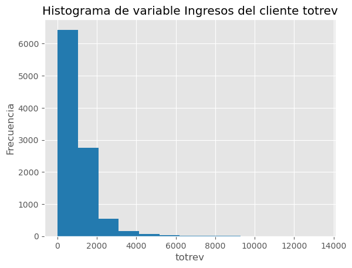

```python
plt.style.use('ggplot')
plt.hist(DF_Bien["totrev"],bins=13,color="#237AAF")
plt.title('Histograma de variable Ingresos del cliente totrev')
plt.xlabel("totrev");plt.ylabel("Frecuencia")
plt.show()
```

```python
print(plt.style.available)
```

[output not shown]

#### Boxplot

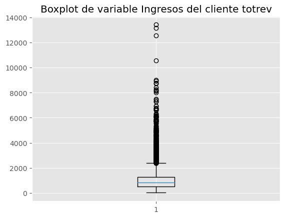

```python
plt.style.use('ggplot')
plt.boxplot(DF_Bien["totrev"])
plt.title('Boxplot de variable Ingresos del cliente totrev')
plt.show()
```

#### Gráficas a partir de `groupby`

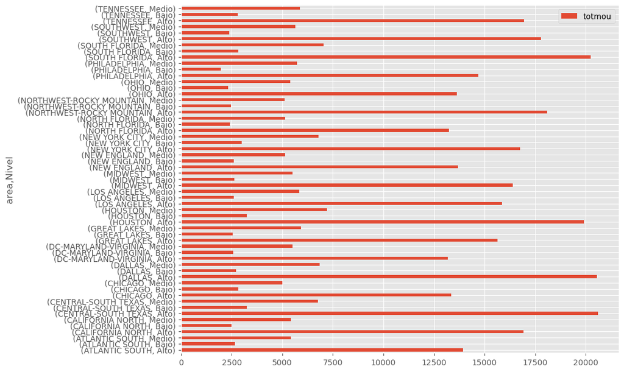

```python
df4=df_con_etiquetas.groupby(['area','Nivel'])[['totmou']].mean()
df4.plot(kind='barh',figsize=(10,8))
plt.show()
```

#### Gráficas de `pandas`

El modulo`.plot()` genera por defecto una gráfica de línea, existen varios gráficos para los `DataFrameGroup`

```
- 'line' : Gráfica de línea
- 'bar' :  Diagrama de barras vertical
- 'barh' : Diagrama de barras horizontal
- 'hist' : histograma
- 'box' : boxplot
- 'kde' : Kernel de densidad
- 'area' : Gráfica de área
- 'pie' : Diagrama de torta
- 'scatter' : Diagrama de dispersión
- 'hexbin' : Diagrama de hexágonos
```

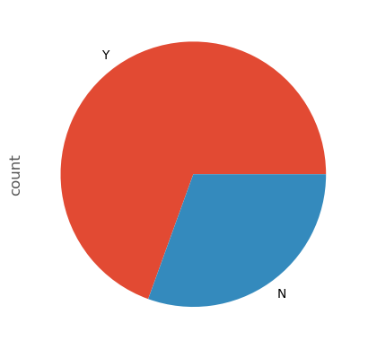

```python
DF_Bien["creditcd_x"].value_counts().plot(kind="pie")
plt.show()
```

Revisando la relación entre las dos variables `totrev` y `totmou`

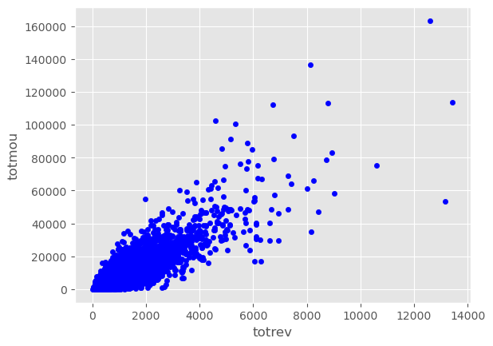

```python
DF_Bien.plot(kind="scatter",x='totrev',y='totmou',c='blue')
```

### `Seaborn`

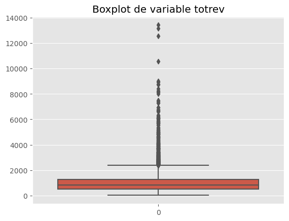

```python
sns.boxplot(DF_Bien["totrev"],orient='v')
plt.title('Boxplot de variable totrev')
plt.show()
```

### Gráficas de parcela

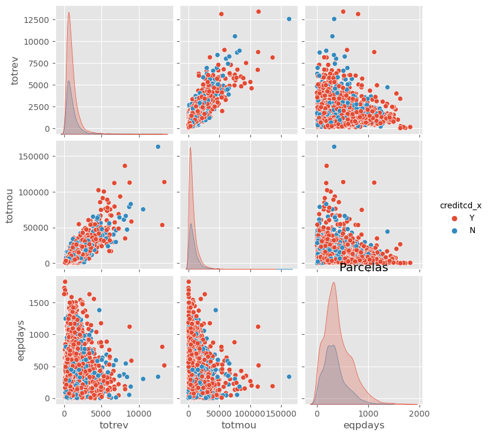

```python
plt.figure(figsize=(116,4))
sns.pairplot(data=DF_Bien, hue='creditcd_x', vars=['totrev','totmou','eqpdays'])
plt.title("Parcelas")
plt.show()
```

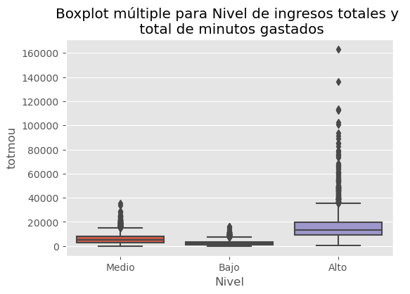

```python
plt.figure(figsize=(6,4))
sns.boxplot(x='Nivel',y='totmou',data=df_con_etiquetas)
plt.title('Boxplot múltiple para Nivel de ingresos totales y \n total de minutos gastados')
plt.show()
```

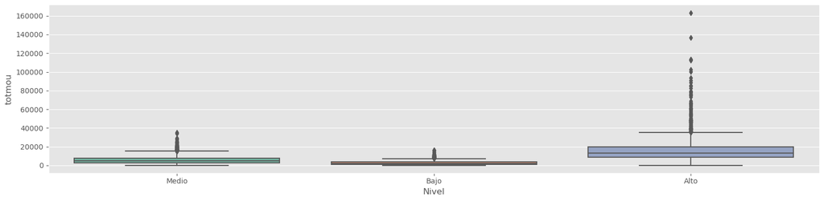

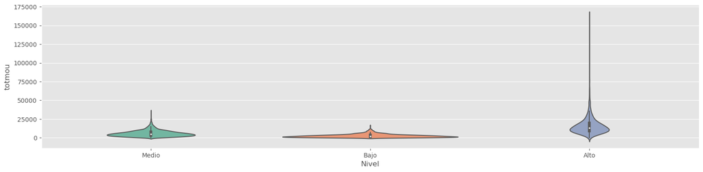

```python
sns.catplot(y="totmou", x="Nivel", kind="box",    data=df_con_etiquetas, height=4, aspect=4, palette='Set2')
sns.catplot(y="totmou", x="Nivel", kind="violin", data=df_con_etiquetas, height=4, aspect=4, palette='Set2')
```

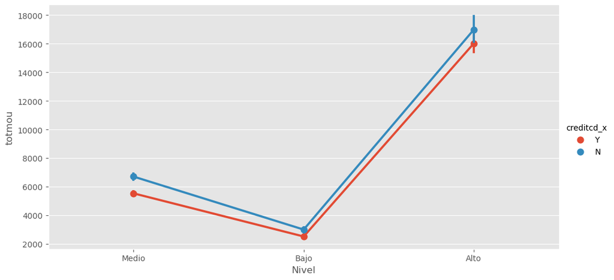

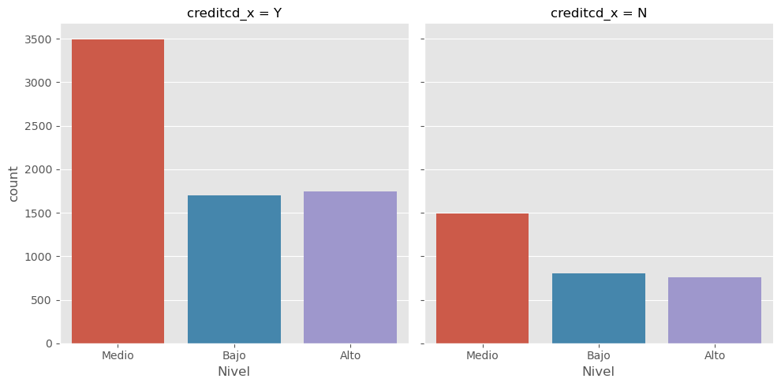

```python
ax = sns.catplot(y="totmou", x="Nivel", hue='creditcd_x', kind='point',data=df_con_etiquetas, aspect=2)
ax = sns.catplot(x="Nivel", kind='count',data=df_con_etiquetas, col='creditcd_x')
```

**¿Existe relación alguna entre el total de minutos usados con la compañía y el ingreso total de los clientes?**

El análisis exploratorio realizado con la totalidad de las variables, nos hace entender y concluir que sí existe relación entre el total de minutos usados totmou y el ingreso total de los clientes tourev. La creación de etiquetas de nivel haciendo uso de los percentiles, ha sido una gran herramienta para poder realizar una serie de gráficas de mayor precisión y que nos brinden mayor información.

Particularmente, los diagramas de dispersión han sido decisivos a la hora de determinar la influencia de los minutos usados en la compañia en el total de ingreso de los clientes, mostrándonos la claridad de la relación que existe entre estas dos variables.

**El hecho de tener crédito afecta alguna de estas dos variables, compruébenlo incluyendo en el diagrama de dispersión una leyenda que indique si tiene crédito o no**

Repetimos la gráfica de parcelas mostrando en naranja la leyenda de crédito sí y en azul crédito no. La información mostrada no es concluyente para afirmar que tener crédito afecta alguna de las variables, pues la dispersión mostrada no genera una tendencia específica de deste fenómeno.

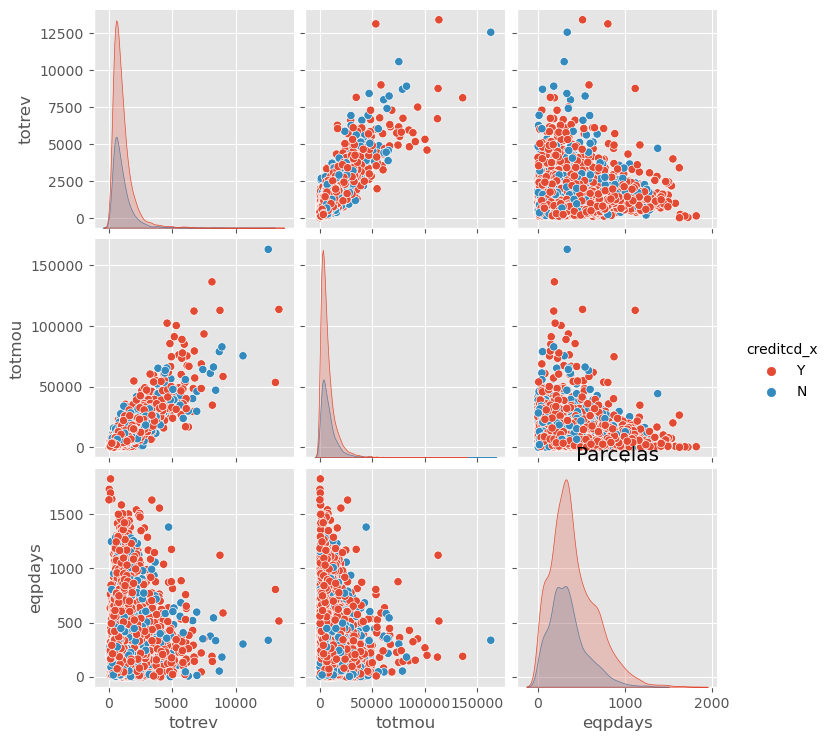

```python
plt.figure(figsize=(116,4))
sns.pairplot(data=DF_Bien, hue='creditcd_x', vars=['totrev','totmou','eqpdays'])
plt.title("Parcelas")
plt.show()
```